# Assignment 3

### Visualization Technique

The visualization technique I am planning to use is the Violin Plot.

A violin plot is a hybrid of a box plot and a kernel density plot. Like a box plot, it shows the median (the white dot at the center of the "violin"), the interquartile range (the black bar at the center of the "violin"), and the upper/lower adjacent values (the black lines stretched from the bar on either side). Unlike a box plot however, it depicts the entire distribution of numeric data using density curves (probability density function). The width of each curve corresponds with the frequency of data points in each region. Hence, unlike a box plot, a violin plot can help us visualize multimodal data (distributions with multiple peaks).

Violin plots are used when the distributions of numeric data need to be observed. They are especially useful when a comparison between distributions of multiple groups (i.e. the peaks, valleys, and tails of density curves) needs to be made. While overlapping density plots for different groups can be difficult to read and interpret, the violin plots for each group can just be placed side-by-side, making comparisons easy. Also unlike histograms which also show the distribution of data, the number of bins need not be specified for violin plots, which gives a more authentic shape of the distribution independent of the number of bins that would be chosen. Other visual elements such as those of Swarm Plot (the dots depicting individual observations), and box plot quartiles can also be overlayed on top of violin plots to provide more insights during comparisons if required.

It is important to consider that violin plots are useful to observe distributions of numeric data and not categorical data. The dataset should have continuous, numerical features. However, comparisons of numeric distributions across categories can be made. A violin plot also does not show sample size. Hence, if groups with different sample sizes are being compared, the sample sizes need to be explicitly made note of.

### Visualization Library

The library I am going to use is Seaborn.

Seaborn is a Python package for creating statistical graphics using Python. It builds on top of matplotlib and integrates closely with pandas data structures. It is an open-source library created by Michael Waskom. It can be easily installed with the following command: pip install seaborn

The library readily displays visualizations in a Jupyter notebook or an IPython terminal with matplotlib mode enabled. Otherwise, the command matplotlib.pyplot.show() may need to be explicitly called.

I chose Seaborn for a number of reasons, the main one of them being that it creates the most aesthetically-pleasing visualizations of any visualization package I have used before. Moreover, its ease of use due to seamless integration with pandas indicates that its plotting functions operate on dataframes and arrays containing whole datasets, making the process of exploratory visualization of the data intuitive and convenient. The aesthetics are also freely and easily customizable. Moreover, Seaborn comes with various built-in statistical plots that just need a single line of code for implementation as opposed to matplotlib.

Seaborn is a declarative interface. Its dataset-oriented framework allows deeper focus on the interpretation of different elements of the plots rather than the nitty-gritty details of how to create them. However, this comes with the disadvantage of not being able to tinker with the finer nuts and bolts of the framework the way we can do with matplotlib. Some parts of the inner workings of the package may be a black box for the uninitiated, offering lesser control. Moreover, Seaborn has certain dependencies such as numpy, scipy, pandas and matplotlib, which means this library cannot be used independently.

### Demonstration

I have procured the Titanic dataset from Kaggle (https://www.kaggle.com/c/titanic/data?select=train.csv). The dataset has been found to be sufficiently clean for further analysis. The main fields I am interested in are:

1. Survived: 0 = passenger did not survive the Titanic disaster, 1 = passenger survived the Titanic disaster
2. Class: 3 = third class passengers, 2 = second class passengers, 1 = first class passengers
3. Gender: gender of passenger i.e. male or female
4. Age: age of passenger

Using a violin plot, I want to see whether there is any difference in survival rates of men and women on comparing the distributions of the passengers based on their age, passenger class and fare.

```python
# import the required libraries
import pandas as pd
import seaborn as sns
import matplotlib.pyplot as plt
import numpy as np
```

```python
# import the Titanic dataset as a pandas dataframe object
df=pd.read_csv("titanic.csv")
```

```python
# inspect the top 5 rows of the dataset
df.head()
```

|  | Survived | Class | Gender | Age | SipSp | ParCh | Fare | Emb |
| --- | --- | --- | --- | --- | --- | --- | --- | --- |
| 0 | 0 | 3 | male | 22.0 | 1 | 0 | 7.2500 | S |
| 1 | 1 | 1 | female | 38.0 | 1 | 0 | 71.2833 | C |
| 2 | 1 | 3 | female | 26.0 | 0 | 0 | 7.9250 | S |
| 3 | 1 | 1 | female | 35.0 | 1 | 0 | 53.1000 | S |
| 4 | 0 | 3 | male | 35.0 | 0 | 0 | 8.0500 | S |

```python
# get an idea of the number of non-null elements in the dataset
df.info()
```

```
<class 'pandas.core.frame.DataFrame'>
RangeIndex: 891 entries, 0 to 890
Data columns (total 8 columns):
 #   Column    Non-Null Count  Dtype
---  ------    --------------  -----
 0   Survived  891 non-null    int64
 1   Class     891 non-null    int64
 2   Gender    891 non-null    object
 3   Age       891 non-null    float64
 4   SipSp     891 non-null    int64
 5   ParCh     891 non-null    int64
 6   Fare      891 non-null    float64
 7   Emb       889 non-null    object
dtypes: float64(2), int64(4), object(2)
memory usage: 55.8+ KB
```

```python
# inspect the "Survived" column
df.Survived.value_counts()
```

```
0    549
1    342
Name: Survived, dtype: int64
```

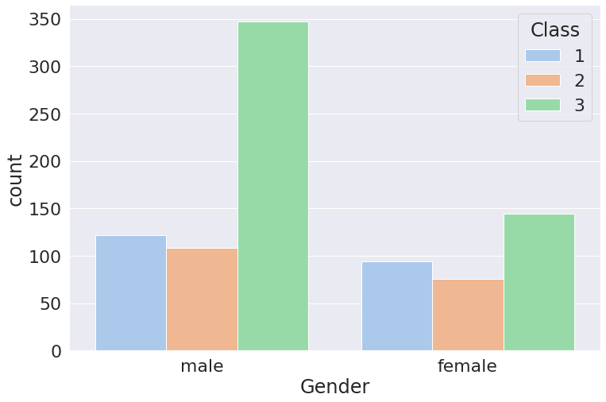

```python
# let us first get an idea of how many male and female passengers were aboard the Titanic, and their passenger classes
plt.figure(figsize=(12,8))
sns.set(font_scale=2, palette="pastel")
sns.countplot(data=df, x="Gender", hue="Class")
plt.show()
```

There were clearly more male passengers than female aboard the titanic. Additionally, the number of male passengers with a Third Class ticket far exceeded those of any other classes in either gender.

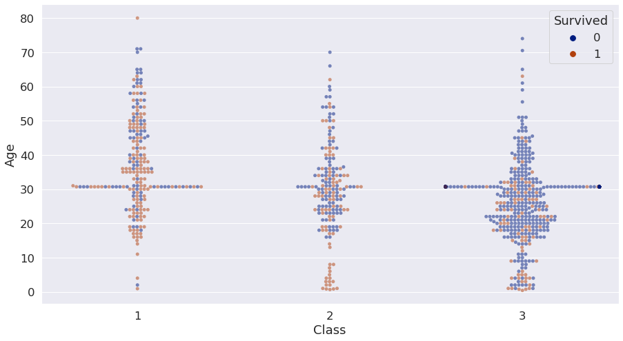

```python
# let us now create a swarm plot to look at the survival status of passengers over the age and class of passengers
plt.figure(figsize=(15,8))
sns.set(font_scale=1.5)
sns.swarmplot(data=df, x="Class", y="Age", hue="Survived", palette="dark", alpha=0.5)
plt.show()
```

With a visual inspection of the dots, it seems like many of the First Class passengers survived, while many of the Third Class passengers died.

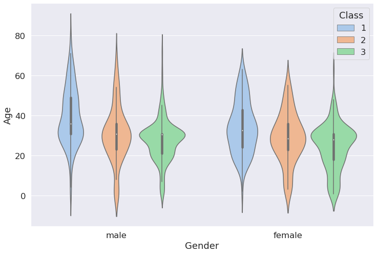

```python
# let us create a violin plot demonstrating the distributions of male and female passengers over class and age
plt.figure(figsize=(12,8))
sns.set(font_scale=1.5)
sns.violinplot(data=df, x="Gender", y="Age", hue="Class", dodge=True, palette="pastel")
plt.show()
```

The Violin Plot helps us determine the spread of the data and also gives us an idea of the median of the data (the white dots at the center of the bars). Setting the parameter dodge=True, we can visualize the violin plots of each group side-by-side for easier comparison. We can see here that passengers in the First Class seemed to be older, while those of the Third Class seemed to be younger in general among both genders.

Seaborn also gives us the functionality to overlay a Swarm Plot on top of this Violin Plot to visualize the individual samples better.

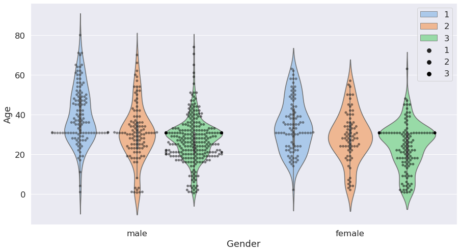

```python
plt.figure(figsize=(15,8))
sns.set(font_scale=1.5)
# Violin Plot
sns.violinplot(data=df, x="Gender", y="Age", hue="Class", dodge=True, palette="pastel")
# Swarm Plot
sns.swarmplot(data=df, x="Gender", y="Age", hue="Class", dodge=True, color="black", alpha=0.5)
plt.legend(loc="upper right")
plt.show()
```

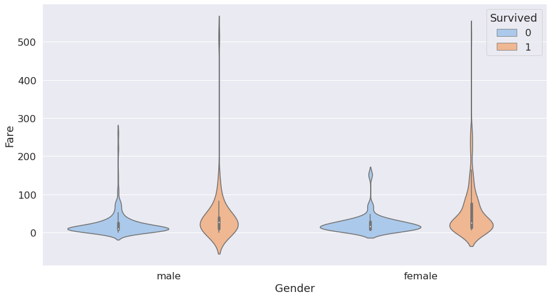

```python
# let us look at how much the passengers paid and their survival status
plt.figure(figsize=(15,8))
sns.set(font_scale=1.5)
sns.violinplot(data=df, x="Gender", y="Fare", hue="Survived", dodge=True, split=False, palette="pastel")
plt.show()
```

There seems to be a strong indication that passengers who paid a significantly high fare for the journey had a better chance of surviving than those who didn't, with the long tails denoting a higher upper limit of fare values among those who survived.

Violin Plots in Seaborn also allow us to split the "violins" into groups along the vertical line separating them to prevent redundancy due to symmetry, and enables better comparison since the "violin halfs" are placed side-by-side. Below, the split occurs on the basis of Gender with Male being on the left hand side and Female being on the right hand side.

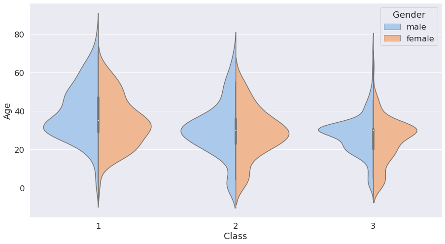

```python
plt.figure(figsize=(15,8))
sns.set(font_scale=1.5)
# set parameter split=True
sns.violinplot(data=df, x="Class", y="Age", hue="Gender", dodge=True, split=True, palette="pastel")
plt.show()
```

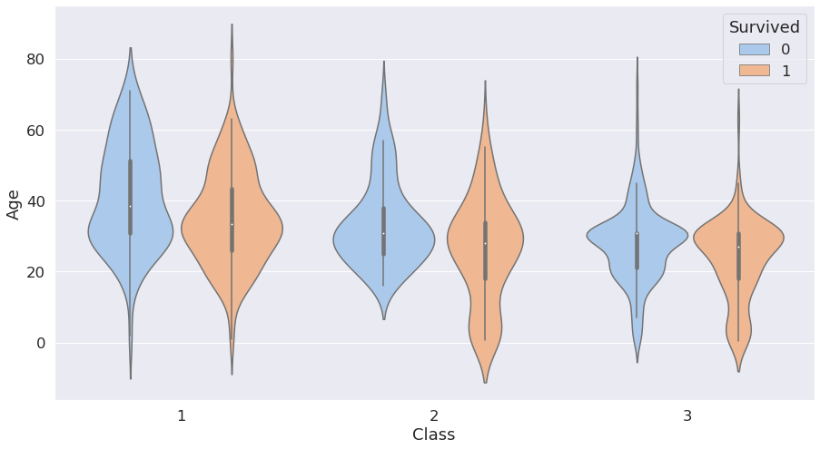

```python
# let us now look at the survival status of each passenger class based on their age
plt.figure(figsize=(15,8))
sns.set(font_scale=1.5)
sns.violinplot(data=df, x="Class", y="Age", hue="Survived", dodge=True, split=False, palette="pastel")
plt.show()
```

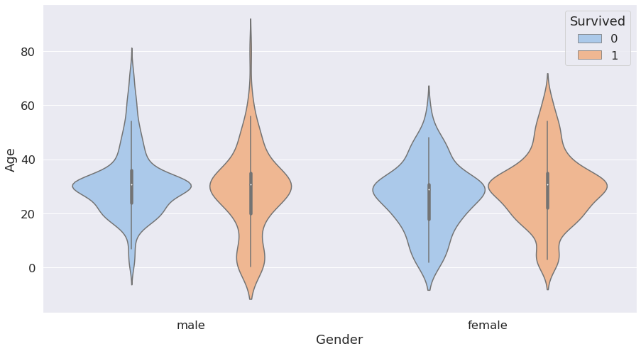

```python
# let us look at the survival status of passengers by age and gender
plt.figure(figsize=(15,8))
sns.set(font_scale=1.5)
# set parameter split=False
sns.violinplot(data=df, x="Gender", y="Age", hue="Survived", dodge=True, split=False, palette="pastel")
plt.show()
```

As an additional explorational aspect of the library for side-by-side comparisons of groups, Seaborn is able to readily create regression plots side-by-side as a facet. The function that enables us to do so is the lmplot, which is a hybrid of the regplot and the FacetGrid functionalities of Seaborn. It essentially denotes a scatter plot with a regression line.

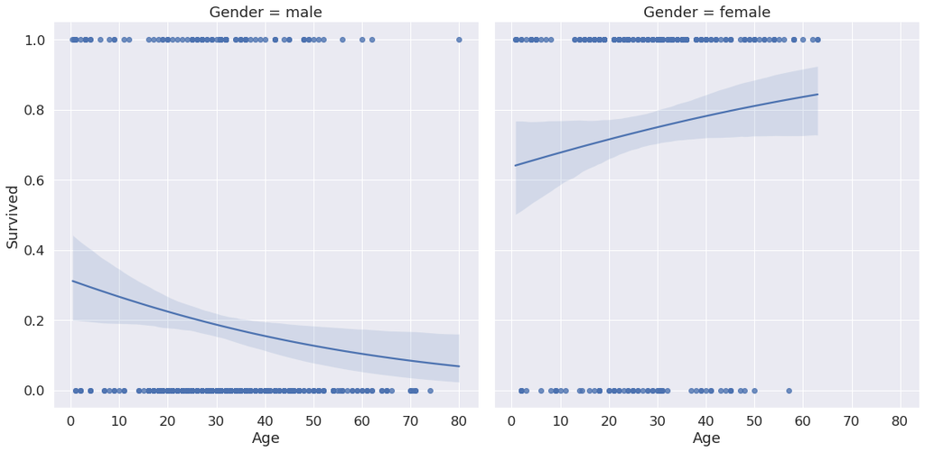

```python
sns.set(font_scale=1.5)
sns.lmplot(data=df, x="Age", y="Survived", aspect=1, height=8, col="Gender", logistic=True)
plt.show()
```

This plot clearly shows that women had a better chance of survival aboard the Titanic compared to men.